# Week 4 - Clustering and Classification

I have never worked with clustering or classification before this week. Therefore, it was incredibly challenging and I really struggled to understand how to interpret these results. I am not really sure why we used this set of this data set to understand crime when the data was related to housing values. Why not use it to look at housing values? I still am not really sure what the two clusters in the final output really represent, any good resources for interpretation would be appreciated!

```r
date()
```

```
## [1] "Tue Nov 29 00:06:08 2022"
```

# Assignment 4: Clustering and Classification

## Relevant Libraries and Packages

```r
library(MASS)
library(tidyr)
library(corrplot)
library(tidyverse)
library(ggplot2)
library(lattice)    # for box plots
library(reshape2)   # converting data to long format
library(factoextra) # k-means visualization
library(ggpubr)     # k-means visualization
library(GGally)     # ggpairs
```

## Step 1: Reading in the Data

```r
# load the data
data(Boston)

# explore the data set
str(Boston)
```

```
## 'data.frame':    506 obs. of  14 variables:
##  $ crim   : num  0.00632 0.02731 0.02729 0.03237 0.06905 ...
##  $ zn     : num  18 0 0 0 0 0 12.5 12.5 12.5 12.5 ...
##  $ indus  : num  2.31 7.07 7.07 2.18 2.18 2.18 7.87 7.87 7.87 7.87 ...
##  $ chas   : int  0 0 0 0 0 0 0 0 0 0 ...
##  $ nox    : num  0.538 0.469 0.469 0.458 0.458 0.458 0.524 0.524 0.524 0.524 ...
##  $ rm     : num  6.58 6.42 7.18 7 7.15 ...
##  $ age    : num  65.2 78.9 61.1 45.8 54.2 58.7 66.6 96.1 100 85.9 ...
##  $ dis    : num  4.09 4.97 4.97 6.06 6.06 ...
##  $ rad    : int  1 2 2 3 3 3 5 5 5 5 ...
##  $ tax    : num  296 242 242 222 222 222 311 311 311 311 ...
##  $ ptratio: num  15.3 17.8 17.8 18.7 18.7 18.7 15.2 15.2 15.2 15.2 ...
##  $ black  : num  397 397 393 395 397 ...
##  $ lstat  : num  4.98 9.14 4.03 2.94 5.33 ...
##  $ medv   : num  24 21.6 34.7 33.4 36.2 28.7 22.9 27.1 16.5 18.9 ...
```

```r
dim(Boston)
```

```
## [1] 506  14
```

*Explanations*

Containing data on housing values in suburbs of Boston, this data set consists of 14 columns and 506 rows. Each variable can be considered one which influences housing value in these suburbs. Explanations for each of the variables can be seen below:

| Variable Name | Variable Type | Explanation |
| --- | --- | --- |
| crim | numeric | per capita crime rate by town |
| zn | numeric | proportion of residential land zoned for lots over 25,000 sq.ft |
| indus | numeric | proportion of non-retail business acres per town |
| chas | integer | Charles River dummy variable (= 1 if tract bounds river; 0 otherwise). |
| nox | numeric | nitrogen oxides concentration (parts per 10 million) |
| rm | numeric | average number of rooms per dwelling. |
| age | numeric | proportion of owner-occupied units built prior to 1940 |
| dis | numeric | weighted mean of distances to five Boston employment centres |
| rad | integer | index of accessibility to radial highways |
| tax | numeric | full-value property-tax rate per $10,000 |
| ptratio | numeric | pupil-teacher ratio by town |
| black | numeric | 1000(Bk−0.63)2 where Bk is the proportion of blacks by town |
| lstat | numeric | lower status of the population (percent) |
| medv | numeric | median value of owner-occupied homes in $1000s |

## Step 2: Graphical and Numerical Exploration

### Graphical Overview

#### Boxplots

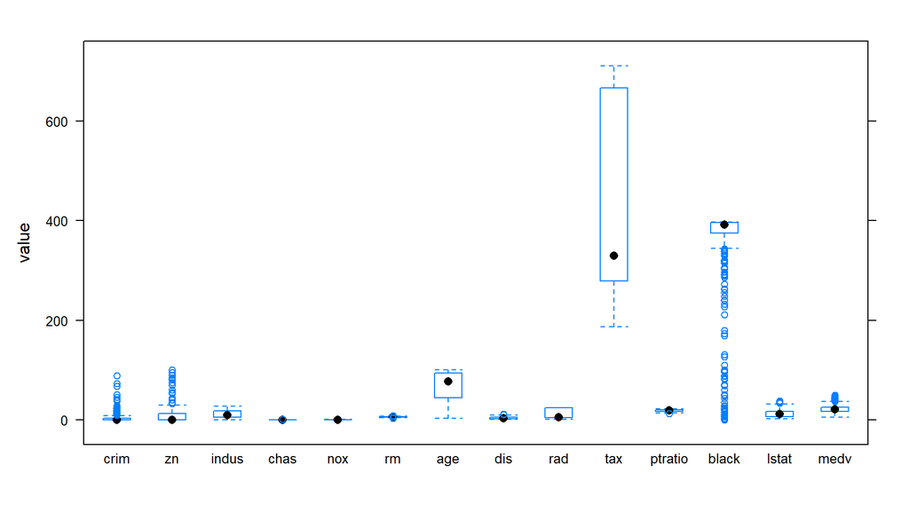

```r
# convert data to long format
Boston_long <- melt(Boston)

# create boxplot for all variables
bwplot(value ~ variable, Boston_long)
```

*Interpretations*

From this initial visualization it is clear that at least three variables (crim, zn and black) posses large numbers of outliers. However, due to the massive variance in scale across variables this is not an effective visualization. Therefore, the variables’ distributions will be visualized in smaller box plot groups.

As we are interested in the variables distributions, we will create a data set containing those which are closest in scale and then visualize those.

```r
# remove columns with largest scale variance
box_boston = subset(Boston, select = -c(tax,black))
```

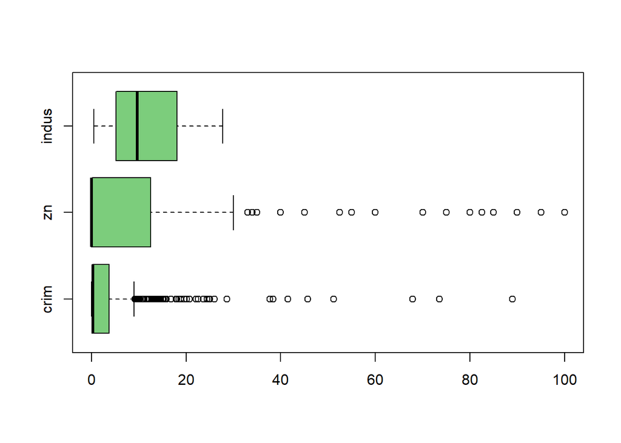

```r
boxplot(box_boston[1:3], col = "palegreen3", horizontal = TRUE)
```

*Interpretations*

A closer look at these boxplots confirms what was shown in the larger plot above. “Crim” and “zn” both possess many outliers and the distributions appear to be skewed to the right. Comparatively, “indus” seems to be distributed more evenly, although it appears to be left-leaning.

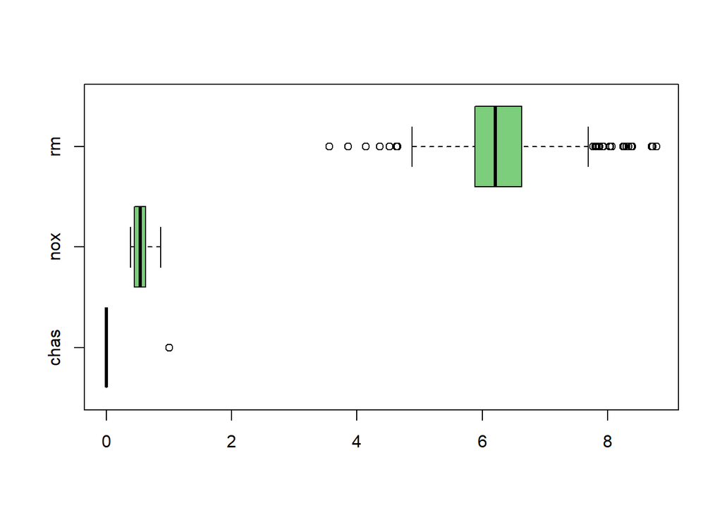

```r
boxplot(box_boston[4:6],  col = "palegreen3", horizontal = TRUE)
```

*Interpretations*

Above, we can see that “rm” possesses quite a few outliers with large tails on both sides of the distribution. Due to scale variance, it is hard to see the distribution of “nox” clearly. Despite this, it can appears to be left-leaning. “Chas” is a dummy variable, it’s value is either 0-1 and is therefore not suited well to box plot visualization.

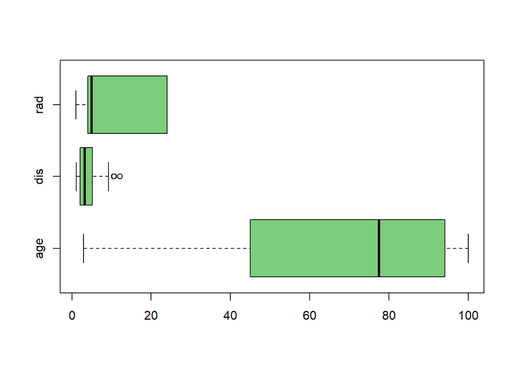

```r
boxplot(box_boston[7:9], col = "palegreen3", horizontal = TRUE)
```

*Interpretations*

“Rad” is a right-leaning distribution. It seems that the average house has has an index of access 10 to the radial highway. As for age, it appears as though around 70% of the buildings in these suburbs were built prior to 1940. The distribution has long tails which makes sense since it is in percent format. For “dis” some outliers appear on the right tail of the data.

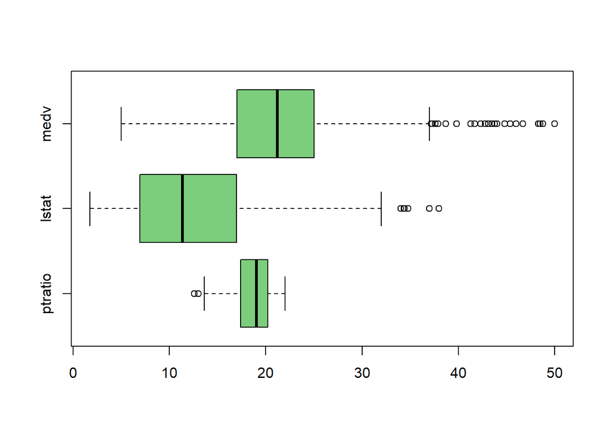

```r
boxplot(box_boston[10:12], col = "palegreen3", horizontal = TRUE)
```

*Interpretations*

#### Relationship

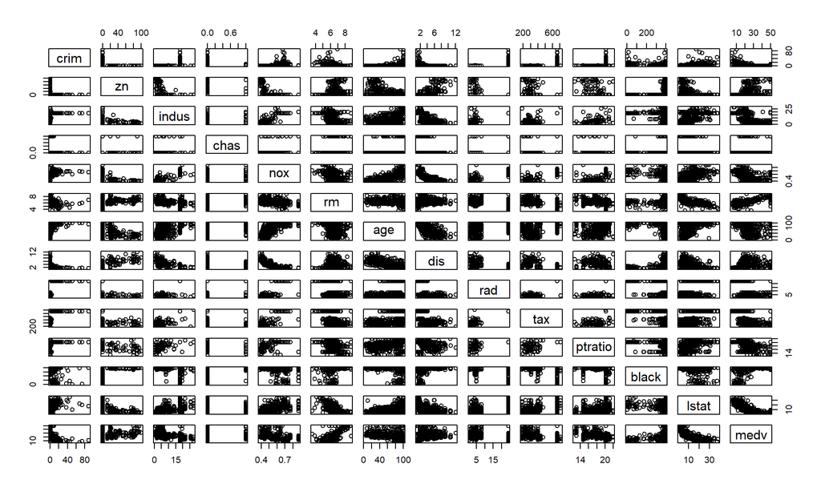

```r
pairs(Boston)
```

*Interpretations*

As this data uses such varying scales it is tough to comment on the relationship between variables in a meaningful way before scaling the data. However, from this scatterplot matrix it can be see that there appears to be a positive relationship between “rm” and “medv”. This makes intuitive sense as the more rooms a house has, the higher value it should be. “Rm” also seems to have a negative relationship with “lstat”, meaning that the higher the percentage lower-status population, the lower the average numer of rooms per home.

*Note:* For some reason I cannot get this visualization to knit in a way where it can be seen properly. If whoever is reading this knows how to format large visualizations like this for knitting, please let me know!

### Numerical Overview

#### Summaries

```r
summary(round(Boston, digits = 2))
```

```
##       crim              zn             indus            chas
##  Min.   : 0.010   Min.   :  0.00   Min.   : 0.46   Min.   :0.00000
##  1st Qu.: 0.080   1st Qu.:  0.00   1st Qu.: 5.19   1st Qu.:0.00000
##  Median : 0.255   Median :  0.00   Median : 9.69   Median :0.00000
##  Mean   : 3.613   Mean   : 11.36   Mean   :11.14   Mean   :0.06917
##  3rd Qu.: 3.678   3rd Qu.: 12.50   3rd Qu.:18.10   3rd Qu.:0.00000
##  Max.   :88.980   Max.   :100.00   Max.   :27.74   Max.   :1.00000
##       nox               rm             age              dis
##  Min.   :0.3800   Min.   :3.560   Min.   :  2.90   Min.   : 1.130
##  1st Qu.:0.4500   1st Qu.:5.883   1st Qu.: 45.02   1st Qu.: 2.100
##  Median :0.5400   Median :6.210   Median : 77.50   Median : 3.210
##  Mean   :0.5542   Mean   :6.285   Mean   : 68.57   Mean   : 3.795
##  3rd Qu.:0.6200   3rd Qu.:6.620   3rd Qu.: 94.08   3rd Qu.: 5.188
##  Max.   :0.8700   Max.   :8.780   Max.   :100.00   Max.   :12.130
##       rad              tax           ptratio          black
##  Min.   : 1.000   Min.   :187.0   Min.   :12.60   Min.   :  0.32
##  1st Qu.: 4.000   1st Qu.:279.0   1st Qu.:17.40   1st Qu.:375.38
##  Median : 5.000   Median :330.0   Median :19.05   Median :391.44
##  Mean   : 9.549   Mean   :408.2   Mean   :18.46   Mean   :356.67
##  3rd Qu.:24.000   3rd Qu.:666.0   3rd Qu.:20.20   3rd Qu.:396.23
##  Max.   :24.000   Max.   :711.0   Max.   :22.00   Max.   :396.90
##      lstat            medv
##  Min.   : 1.73   Min.   : 5.00
##  1st Qu.: 6.95   1st Qu.:17.02
##  Median :11.36   Median :21.20
##  Mean   :12.65   Mean   :22.53
##  3rd Qu.:16.95   3rd Qu.:25.00
##  Max.   :37.97   Max.   :50.00
```

*Interpretations*

Results from the numerical summary confirm the distributions which were visualized graphically above. Each variable has a varying scale which makes it hard to compare means across variables. However, we can see that both “tax” and “black” have large ranges which confirm their respective boxplots seen in the first visualization.

To make the data more comparable we will now standardize the data set.

### Step 3: Standardize data set & variable creation

#### Standardize

```r
# center and standardize variables
boston_scaled <- scale(Boston)

# summaries of the scaled variables
summary(boston_scaled)
```

```
##       crim                 zn               indus              chas
##  Min.   :-0.419367   Min.   :-0.48724   Min.   :-1.5563   Min.   :-0.2723
##  1st Qu.:-0.410563   1st Qu.:-0.48724   1st Qu.:-0.8668   1st Qu.:-0.2723
##  Median :-0.390280   Median :-0.48724   Median :-0.2109   Median :-0.2723
##  Mean   : 0.000000   Mean   : 0.00000   Mean   : 0.0000   Mean   : 0.0000
##  3rd Qu.: 0.007389   3rd Qu.: 0.04872   3rd Qu.: 1.0150   3rd Qu.:-0.2723
##  Max.   : 9.924110   Max.   : 3.80047   Max.   : 2.4202   Max.   : 3.6648
##       nox                rm               age               dis
##  Min.   :-1.4644   Min.   :-3.8764   Min.   :-2.3331   Min.   :-1.2658
##  1st Qu.:-0.9121   1st Qu.:-0.5681   1st Qu.:-0.8366   1st Qu.:-0.8049
##  Median :-0.1441   Median :-0.1084   Median : 0.3171   Median :-0.2790
##  Mean   : 0.0000   Mean   : 0.0000   Mean   : 0.0000   Mean   : 0.0000
##  3rd Qu.: 0.5981   3rd Qu.: 0.4823   3rd Qu.: 0.9059   3rd Qu.: 0.6617
##  Max.   : 2.7296   Max.   : 3.5515   Max.   : 1.1164   Max.   : 3.9566
##       rad               tax             ptratio            black
##  Min.   :-0.9819   Min.   :-1.3127   Min.   :-2.7047   Min.   :-3.9033
##  1st Qu.:-0.6373   1st Qu.:-0.7668   1st Qu.:-0.4876   1st Qu.: 0.2049
##  Median :-0.5225   Median :-0.4642   Median : 0.2746   Median : 0.3808
##  Mean   : 0.0000   Mean   : 0.0000   Mean   : 0.0000   Mean   : 0.0000
##  3rd Qu.: 1.6596   3rd Qu.: 1.5294   3rd Qu.: 0.8058   3rd Qu.: 0.4332
##  Max.   : 1.6596   Max.   : 1.7964   Max.   : 1.6372   Max.   : 0.4406
##      lstat              medv
##  Min.   :-1.5296   Min.   :-1.9063
##  1st Qu.:-0.7986   1st Qu.:-0.5989
##  Median :-0.1811   Median :-0.1449
##  Mean   : 0.0000   Mean   : 0.0000
##  3rd Qu.: 0.6024   3rd Qu.: 0.2683
##  Max.   : 3.5453   Max.   : 2.9865
```

```r
# class of the boston_scaled object
class(boston_scaled)
```

```
## [1] "matrix" "array"
```

```r
# change the object to data frame
boston_scaled <- as.data.frame(boston_scaled)
```

*Interpretations*

After standardizing, we can see that many variable values have become negative. The maximum values are also much closer across all variables. This step is crucial to perform Linear Discriminant Analysis (LDA) as LDA works under the assumption that each of the predictor variables have the same variance.

#### Categorical variable creation

```r
# create a quantile vector of crim
bins <- quantile(boston_scaled$crim)

# create a categorical variable 'crime'
crime <- cut(boston_scaled$crim,
             breaks = bins,
             include.lowest = TRUE,
             labels = c("low", "med_low", "med_high", "high"))

# remove original crim from the dataset
boston_scaled <- dplyr::select(boston_scaled, -crim)

# add the new categorical value to scaled data
boston_scaled <- data.frame(boston_scaled, crime)
```

#### Train and Test set

```r
boston_scaled$crime <- factor(boston_scaled$crime,
                              levels = c("low",
                                         "med_low",
                                         "med_high",
                                         "high"))

# choose randomly 80% of the rows in data set
ind <- sample(nrow(boston_scaled),  size = nrow(boston_scaled) * 0.8)

# create train set
train <- boston_scaled[ind,]

# create test set
test <- boston_scaled[-ind,]
```

## Step 4: Linear Discriminant Analysis

```r
# linear discriminant analysis
lda.fit <- lda(crime ~ ., data = train)

# the function for lda biplot arrows
lda.arrows <- function(x, myscale = 1, arrow_heads = 0.1, color = "red", tex = 0.75, choices = c(1,2)){
  heads <- coef(x)
  arrows(x0 = 0, y0 = 0,
         x1 = myscale * heads[,choices[1]],
         y1 = myscale * heads[,choices[2]], col=color, length = arrow_heads)
  text(myscale * heads[,choices], labels = row.names(heads),
       cex = tex, col=color, pos=3)
}

# target classes as numeric
classes <- as.numeric(train$crime)

# plot the lda results
plot(lda.fit, dimen = 2, col = classes, pch = classes)
lda.arrows
```

```
## function(x, myscale = 1, arrow_heads = 0.1, color = "red", tex = 0.75, choices = c(1,2)){
##   heads <- coef(x)
##   arrows(x0 = 0, y0 = 0,
##          x1 = myscale * heads[,choices[1]],
##          y1 = myscale * heads[,choices[2]], col=color, length = arrow_heads)
##   text(myscale * heads[,choices], labels = row.names(heads),
##        cex = tex, col=color, pos=3)
## }
```

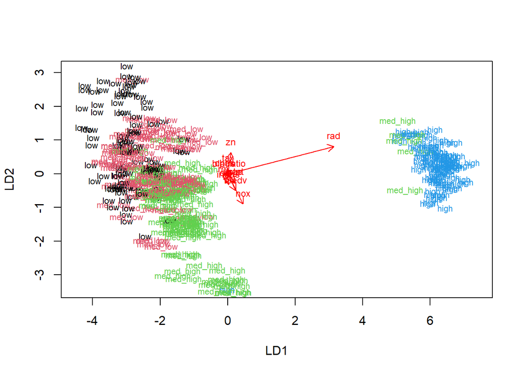

```r
lda.arrows(lda.fit, myscale = 1)
```

*Interpretations*

From the length of the arrows we can see that “rad”, “nox”, and “zn” have the largest variation in the data set.Unfortunately, due to overlapping values it is hard to interpret the angles- which represent the relationship - between the arrows. Despite these difficulties, a potential right-angle can be seen between “rad” and “nox” meaning that they are not highly correlated.

## Step 5: Cross Tabulation

```r
# save the correct classes from test data
correct_classes <- test$crime

# remove the crime variable from test data
test <- dplyr::select(test, -crime)

# predict classes with test data
lda.pred <- predict(lda.fit, newdata = test)

# cross tabulate the results
table(correct = correct_classes, predicted = lda.pred$class)
```

```
##           predicted
## correct    low med_low med_high high
##   low       17       7        2    0
##   med_low    3      14        5    0
##   med_high   0      11       14    1
##   high       0       0        0   28
```

*Interpretations*

We can calculate the accuracy of the model following:

$$Accuracy = \frac{\text{Number of correct predictions}}{\text{Total
number of predictions}}$$